# 6 Newport and CalCOFI time-depth

```r
cciea_yr <- 2024



ds_id <- 'cciea_OC_ARG'
ts_id_list = list('cciea_OC_ARG2')


# Source some local code
source("script_region.R")
```

**Description** Time versus depth profiles of water temperatures off of Newport, Oregon and San Diego, California demonstrate the extent of recent warm and cool anomalies into the water column, as well as spatial and temporal dynamics of these anomalies.

**Metafile name** /home/isaac/Work/IEA/2024/tech_document/CCIEA_metadata_2024-09-26.xlsx

**Indicator Category** Climate and Ocean Drivers

**Data Steward** Schroeder

**Erddap Dataset ID** NA

**CCIEA timeseries ID** NA

**Region** NA (44.7N)

**Public availability statement** Source data are publicly available.

**Data sources** Newport Hydrographic (NH) line temperature data are from J. Fisher, NMFS/NWFSC, OSU. CalCOFI hydrographic line data are from https://calcofi.org/data.html.

**Additional Information**

**Figures**

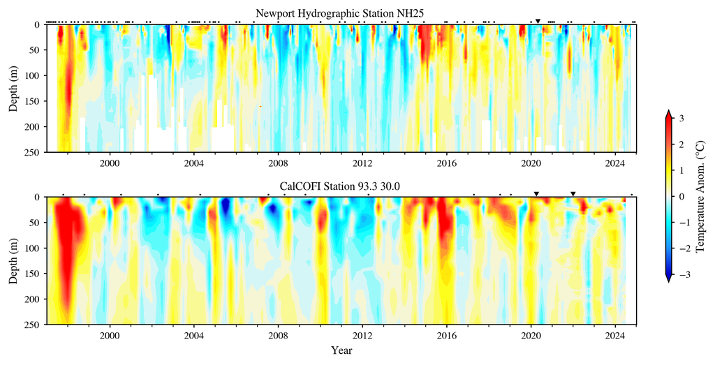

Figure 6.1: Time–depth temperature anomalies for hydrographic stations NH25 (July 1997 to October 2024. ) and CalCOFI 93.30 (January 1997 to August 2024. ). The NH25 (top plot) temperature anomalies are monthly means and the time interval is one month (i.e., 12 values per year). The CalCOFI (bottom plot) temperature anomalies are quarterly means and the time intervals are seasons (i.e., four values per year). Months or quarters not sampled are marked with a black circle along the top axis; missing samples are filled using bi-linear interpolation. Sampling missed due to Covid restrictions are marked with a black triangle. The spring 2020 and winter 2022 CalCOFI temperature profiles were filled using daily mean temperature data on April 15, 2020 and January 31, 2022 from a data assimilative ocean model (NRT ROMS; https://oceanmodeling.ucsc.edu/ccsnrt/).

**2024 Conditions**